# Ratik_29A_Project 2_Time series analysis

[output not shown]

[output not shown]

```
    Box-Pierce test

data:  NESTLEIND.NS_return
X-squared = 5.2778, df = 1, p-value = 0.0216
```

Analysis:

Action: Given the presence of autocorrelation, it may be advisable to consider an autoARIMA model for time series forecasting. AutoARIMA can help in automatically selecting an appropriate ARIMA model with differencing to account for the observed autocorrelation.

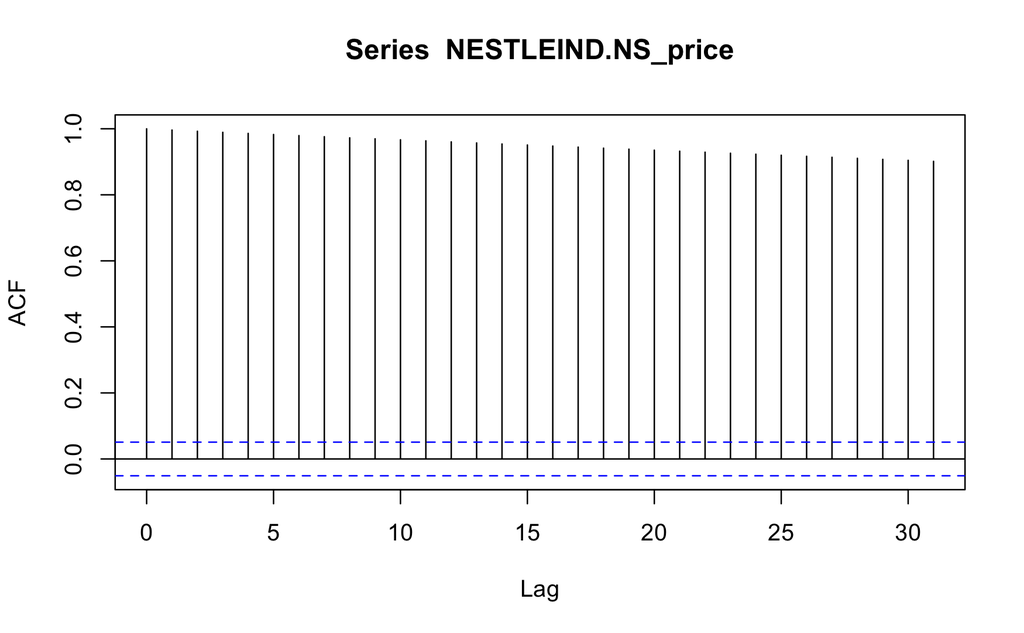

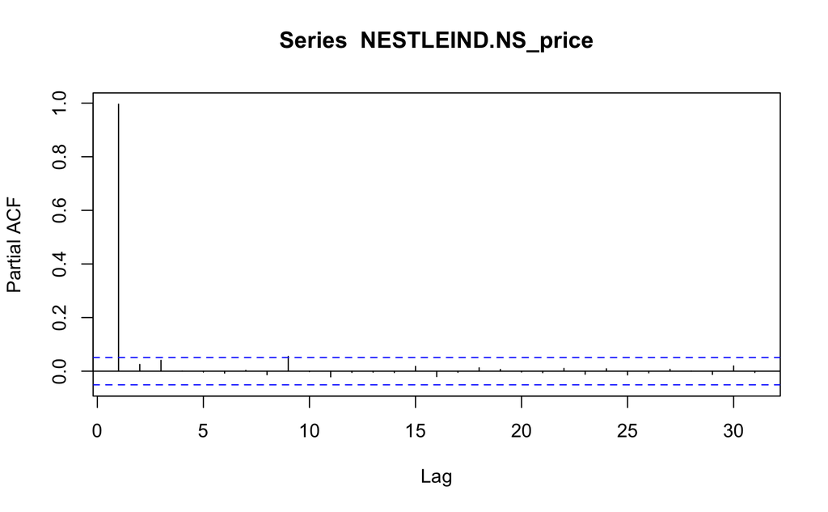

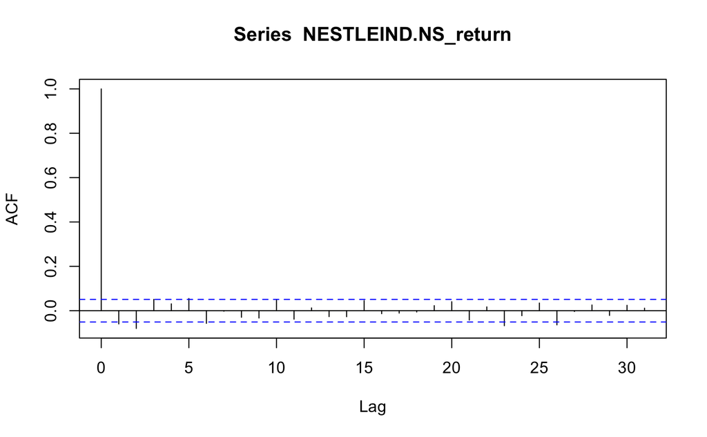

```r
acf(NESTLEIND.NS_price) # ACF of JJ Series
pacf(NESTLEIND.NS_price) # PACF of JJ Series


acf(NESTLEIND.NS_return) # ACF of JJ Difference (Stationary) Series
```

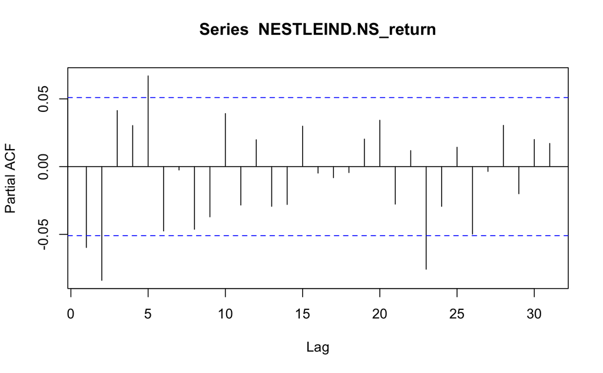

```r
pacf(NESTLEIND.NS_return) # PACF of JJ Difference (Stationary) Series
```

```r
NA
NA
```

```r
arma_pq_ds = auto.arima(NESTLEIND.NS_return); arma_pq_ds
```

```
Series: NESTLEIND.NS_return
ARIMA(4,0,5) with non-zero mean

Coefficients:
          ar1      ar2      ar3      ar4     ma1     ma2     ma3     ma4     ma5   mean
      -0.9539  -0.3448  -0.2026  -0.5244  0.8988  0.2138  0.1706  0.5901  0.0671  1e-03
s.e.   0.1726   0.2817   0.2528   0.1451  0.1732  0.2649  0.2253  0.1252  0.0350  4e-04

sigma^2 = 0.0002098:  log likelihood = 4172.06
AIC=-8322.11   AICc=-8321.93   BIC=-8263.81
```

```r
arma_pq = auto.arima(NESTLEIND.NS_price); arma_pq
```

```
Series: NESTLEIND.NS_price
ARIMA(2,1,2) with drift

Coefficients:
         ar1      ar2      ma1     ma2   drift
      0.6985  -0.7192  -0.7801  0.7071  1.3649
s.e.  0.1425   0.0839   0.1515  0.0859  0.4911

sigma^2 = 434.2:  log likelihood = -6591.99
AIC=13195.98   AICc=13196.04   BIC=13227.78
```

Analysis:

Objective: To perform autoARIMA modeling on the daily returns (‘NESTLEIND.NS_return’) and adjusted closing prices (‘NESTLEIND.NS_price’) of NESTLEIND.NS stock. Analysis: Used the ‘auto.arima’ function to automatically select the ARIMA model for both returns and prices. Results:

Implication: The autoARIMA models provide a statistical framework to capture the underlying patterns in both daily returns and adjusted closing prices of NESTLEIND.NS stock. These models can be used for forecasting future values, and the AIC, AICc, and BIC values help in model comparison.

Note: Interpretation of the coefficients and model selection details may require further analysis based on the specific context of the financial data.

```r
arma13 = arima(NESTLEIND.NS_return, order = c(5, 0, 4)); arma13
```

```
Call:
arima(x = NESTLEIND.NS_return, order = c(5, 0, 4))

Coefficients:
          ar1      ar2      ar3      ar4     ar5     ma1     ma2     ma3     ma4  intercept
      -0.8625  -0.2815  -0.1937  -0.5004  0.0639  0.8071  0.1578  0.1712  0.5652      1e-03
s.e.   0.1680   0.2733   0.2439   0.1547  0.0348  0.1673  0.2576  0.2174  0.1324      4e-04

sigma^2 estimated as 0.0002084:  log likelihood = 4171.99,  aic = -8321.99
```

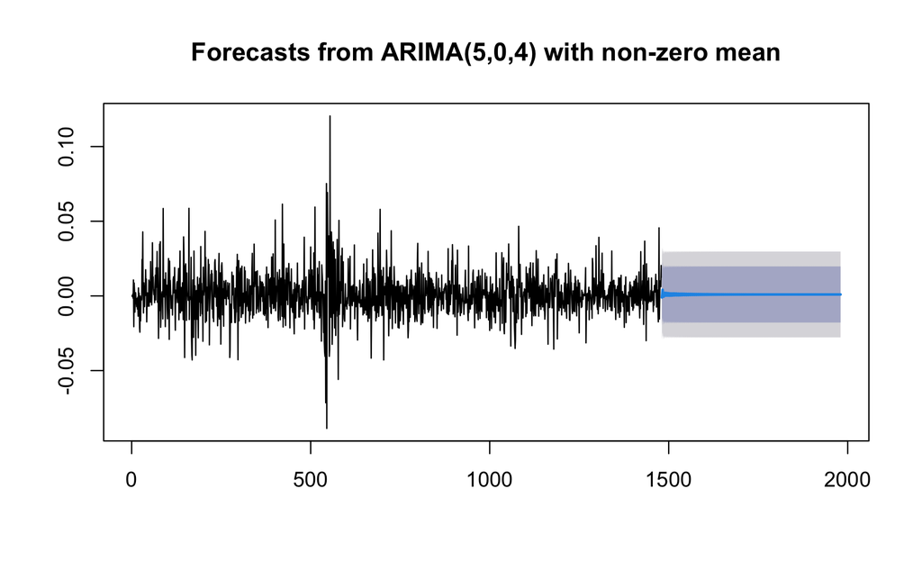

```r
ds_fpq = forecast(arma13, h = 500)
plot(ds_fpq)
```

Analysis:

Objective: To fit an ARIMA(5, 0, 4) model to the daily returns (‘NESTLEIND.NS_return’) of NESTLEIND.NS stock and generate forecasts. Analysis: Used the ‘arima’ function to fit the ARIMA model and the ‘forecast’ function to generate forecasts. Results:

ARIMA Model (5, 0, 4): Coefficients: - AR: ar1 to ar5 - MA: ma1 to ma4 - Intercept term - sigma^2 estimated as 0.0002084: log likelihood = 4172, aic = -8322 Forecasting: Generated forecasts for the next 500 time points using the fitted ARIMA model.

Plot: The plot displays the original time series of daily returns along with the forecasted values.

Implication: The ARIMA(5, 0, 4) model is fitted to the historical daily returns of NESTLEIND.NS stock, providing insights into the underlying patterns. The generated forecast can be used for future predictions, and the plot visually represents the model’s performance.

Note: Interpretation of coefficients and model evaluation details may require further analysis based on the specific context of the financial data.

```r
lb_test_ds_A = Box.test(arma13$residuals); lb_test_ds_A
```

```
    Box-Pierce test

data:  arma13$residuals
X-squared = 8.1429e-05, df = 1, p-value = 0.9928
```

Analysis:

Ljung-Box Test for Autocorrelation on Residuals:

X-squared = 8.1429e-05, df = 1, p-value = 0.9928

Action: The absence of autocorrelation in residuals is a positive outcome, indicating that the ARIMA model adequately captures the temporal patterns in the time series.

Note: Interpretation may vary based on the specific context of the financial data and the assumptions underlying the time series analysis.

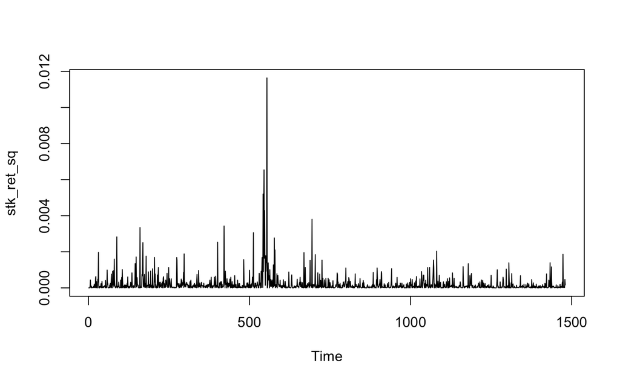

```r
stk_ret_sq = arma13$residuals^2 # Return Variance (Since Mean Returns is approx. 0)
plot(stk_ret_sq)
stk_ret_sq_box_test = Box.test(stk_ret_sq, lag = 10) # H0: Return Variance Series is Not Serially Correlated
stk_ret_sq_box_test # Inference : Return Variance Series is Heteroskedastic (Has Volatility Clustering)
```

```
    Box-Pierce test

data:  stk_ret_sq
X-squared = 520.09, df = 10, p-value < 2.2e-16
```

```r
# Test for Volatility Clustering or Heteroskedasticity: ARCH Test
stk_ret_arch_test = ArchTest(arma13$residuals, lags = 10) # H0: No ARCH Effects
stk_ret_arch_test # Inference : Return Series is Heteroskedastic (Has Volatility Clustering)
```

```
    ARCH LM-test; Null hypothesis: no ARCH effects

data:  arma13$residuals
Chi-squared = 214.89, df = 10, p-value < 2.2e-16
```

Analysis: Objective: To test for volatility clustering or heteroskedasticity in the residuals of the ARIMA(5, 0, 4) model. Analysis: Conducted Box test and ARCH test on the squared residuals to assess the presence of volatility clustering. Results:

1. Box Test for Volatility Clustering: X-squared = 520.09, df = 10, p-value < 2.2e-16

   Inference: The Box test indicates significant evidence against the null hypothesis, suggesting that the return variance series exhibits volatility clustering or heteroskedasticity.
2. ARCH Test for Volatility Clustering: Chi-squared = 214.89, df = 10, p-value < 2.2e-16

   Inference: The ARCH test also provides strong evidence against the null hypothesis, supporting the presence of ARCH effects in the return series. This implies that the returns have volatility clustering.

Implication: The results from both tests suggest that the residuals of the ARIMA(5, 0, 4) model exhibit volatility clustering or heteroskedasticity. Understanding and accounting for this pattern in volatility is essential for risk management and forecasting.

Note: Interpretation may vary based on the specific context of the financial data and the assumptions underlying the time series analysis.

```r
garch_model1 = ugarchspec(variance.model = list(model = 'sGARCH', garchOrder = c(1,1)), mean.model = list(armaOrder = c(0,0), include.mean = TRUE))
nse_ret_garch1 = ugarchfit(garch_model1, data = arma13$residuals); nse_ret_garch1
```

```
*---------------------------------*
*          GARCH Model Fit        *
*---------------------------------*

Conditional Variance Dynamics
-----------------------------------
GARCH Model : sGARCH(1,1)
Mean Model  : ARFIMA(0,0,0)
Distribution    : norm

Optimal Parameters
------------------------------------
        Estimate  Std. Error  t value Pr(>|t|)
mu     -0.000107    0.000336  -0.3202  0.74882
omega   0.000008    0.000000  18.3258  0.00000
alpha1  0.063346    0.005384  11.7648  0.00000
beta1   0.894932    0.008562 104.5290  0.00000

Robust Standard Errors:
        Estimate  Std. Error  t value Pr(>|t|)
mu     -0.000107    0.000338 -0.31774  0.75068
omega   0.000008    0.000001 10.12415  0.00000
alpha1  0.063346    0.004695 13.49120  0.00000
beta1   0.894932    0.010196 87.77367  0.00000

LogLikelihood : 4266.191

Information Criteria
------------------------------------

Akaike       -5.7597
Bayes        -5.7454
Shibata      -5.7597
Hannan-Quinn -5.7544

Weighted Ljung-Box Test on Standardized Residuals
------------------------------------
                        statistic p-value
Lag[1]                    0.05121  0.8210
Lag[2*(p+q)+(p+q)-1][2]   0.47904  0.7035
```

[output cut: 19 more lines]

```
Nyblom stability test
------------------------------------
Joint Statistic:  22.0386
Individual Statistics:
mu     0.1461
omega  4.3633
alpha1 0.5998
beta1  0.7088

Asymptotic Critical Values (10% 5% 1%)
Joint Statistic:         1.07 1.24 1.6
Individual Statistic:    0.35 0.47 0.75

Sign Bias Test
------------------------------------
```

|  | t-value | prob | sig |
| --- | --- | --- | --- |
| Sign Bias | 1.0364900 | 0.300143504 |  |
| Negative Sign Bias | 2.6407934 | 0.008358536 | *** |
| Positive Sign Bias | 0.1013824 | 0.919260708 |  |
| Joint Effect | 7.3069062 | 0.062733044 | * |

```
Adjusted Pearson Goodness-of-Fit Test:
------------------------------------
  group statistic p-value(g-1)
1    20     77.68    4.662e-09
2    30     96.99    2.952e-09
3    40    104.97    5.832e-08
4    50    112.84    6.042e-07


Elapsed time : 0.2001059
```

```r
garch_model2 = ugarchspec(variance.model = list(model = 'sGARCH', garchOrder = c(1,1)), mean.model = list(armaOrder = c(4,5), include.mean = FALSE))
nse_ret_garch2 = ugarchfit(garch_model2, data = arma13$residuals); nse_ret_garch2
```

```
*---------------------------------*
*          GARCH Model Fit        *
*---------------------------------*

Conditional Variance Dynamics
-----------------------------------
GARCH Model : sGARCH(1,1)
Mean Model  : ARFIMA(4,0,5)
Distribution    : norm

Optimal Parameters
------------------------------------
        Estimate  Std. Error     t value Pr(>|t|)
ar1     0.020899    0.028053  7.4498e-01  0.45628
ar2    -0.058183    0.010736 -5.4195e+00  0.00000
ar3     0.025519    0.027392  9.3162e-01  0.35153
ar4     0.931297    0.010307  9.0354e+01  0.00000
ma1    -0.027895    0.037281 -7.4825e-01  0.45431
ma2     0.059522    0.001002  5.9410e+01  0.00000
ma3    -0.034248    0.023692 -1.4456e+00  0.14830
ma4    -0.942482    0.000078 -1.2113e+04  0.00000
ma5    -0.004458    0.026934 -1.6550e-01  0.86855
omega   0.000008    0.000000  1.5492e+01  0.00000
alpha1  0.060477    0.005255  1.1509e+01  0.00000
beta1   0.900767    0.008280  1.0878e+02  0.00000

Robust Standard Errors:
        Estimate  Std. Error     t value Pr(>|t|)
ar1     0.020899    0.020152  1.0371e+00 0.299709
ar2    -0.058183    0.011021 -5.2791e+00 0.000000
ar3     0.025519    0.018501  1.3793e+00 0.167800
ar4     0.931297    0.009549  9.7530e+01 0.000000
ma1    -0.027895    0.031163 -8.9512e-01 0.370721
ma2     0.059522    0.001036  5.7431e+01 0.000000
ma3    -0.034248    0.016359 -2.0935e+00 0.036304
ma4    -0.942482    0.000071 -1.3198e+04 0.000000
ma5    -0.004458    0.027387 -1.6276e-01 0.870703
omega   0.000008    0.000001  8.5209e+00 0.000000
alpha1  0.060477    0.004399  1.3747e+01 0.000000
beta1   0.900767    0.009816  9.1770e+01 0.000000
```

[output cut: 43 more lines]

```
ma1    0.04597
ma2    0.08457
ma3    0.04964
ma4    0.09192
ma5    0.04639
omega  3.65095
alpha1 0.59236
beta1  0.70169

Asymptotic Critical Values (10% 5% 1%)
Joint Statistic:         2.69 2.96 3.51
Individual Statistic:    0.35 0.47 0.75

Sign Bias Test
------------------------------------
```

|  | t-value | prob | sig |
| --- | --- | --- | --- |
| Sign Bias | 0.8222160 | 0.41108689 |  |
| Negative Sign Bias | 2.2464470 | 0.02482283 | ** |
| Positive Sign Bias | 0.1666323 | 0.86768219 |  |
| Joint Effect | 5.4631656 | 0.14085840 |  |

```
Adjusted Pearson Goodness-of-Fit Test:
------------------------------------
  group statistic p-value(g-1)
1    20      69.0    1.348e-07
2    30      81.3    7.470e-07
3    40     102.5    1.291e-07
4    50     142.3    4.966e-11


Elapsed time : 0.4108779
```

```r
# Test for Volatility Clustering or Heteroskedasticity: ARCH Test
gar_resd = residuals(nse_ret_garch2)^2
stk_ret_arch_test1 = ArchTest(gar_resd, lags = 1) # H0: No ARCH Effects
stk_ret_arch_test1 # Inference : Return Series is Heteroskedastic (Has Volatility Clustering)
```

```
    ARCH LM-test; Null hypothesis: no ARCH effects

data:  gar_resd
Chi-squared = 6.5372, df = 1, p-value = 0.01056
```

Analysis: Objective: To fit GARCH models to the residuals of the ARIMA(5, 0, 4) model and test for volatility clustering. Analysis: Fitted two GARCH models (‘garch_model1’ and ‘garch_model2’) to the residuals and performed an ARCH test on squared residuals. Results:

Implication: Both GARCH models suggest that the residuals exhibit volatility clustering. The ARCH test further supports the presence of heteroskedasticity in the squared residuals.

Note: Interpretation may vary based on the specific context of the financial data and the assumptions underlying the time series analysis.

```r
garch_modelf = ugarchspec(variance.model = list(model = 'sGARCH', garchOrder = c(1,1)), mean.model = list(armaOrder = c(4,5), include.mean = FALSE))
stk_ret_garch = ugarchfit(garch_modelf, data = NESTLEIND.NS_return); stk_ret_garch
```

```
*---------------------------------*
*          GARCH Model Fit        *
*---------------------------------*

Conditional Variance Dynamics
-----------------------------------
GARCH Model : sGARCH(1,1)
Mean Model  : ARFIMA(4,0,5)
Distribution    : norm

Optimal Parameters
------------------------------------
        Estimate  Std. Error  t value Pr(>|t|)
ar1    -1.103740    0.016796  -65.714        0
ar2    -0.873307    0.040315  -21.662        0
ar3    -0.836997    0.039988  -20.931        0
ar4    -0.829522    0.017868  -46.426        0
ma1     1.048849    0.002737  383.277        0
ma2     0.760029    0.019261   39.459        0
ma3     0.715485    0.011540   61.998        0
ma4     0.749961    0.000181 4134.244        0
ma5    -0.027693    0.001334  -20.754        0
omega   0.000008    0.000000   18.500        0
alpha1  0.065691    0.006194   10.605        0
beta1   0.892730    0.008757  101.950        0

Robust Standard Errors:
        Estimate  Std. Error   t value Pr(>|t|)
ar1    -1.103740    0.017818  -61.9441        0
ar2    -0.873307    0.048088  -18.1607        0
ar3    -0.836997    0.049272  -16.9873        0
ar4    -0.829522    0.021007  -39.4873        0
ma1     1.048849    0.003309  316.9718        0
ma2     0.760029    0.022391   33.9441        0
ma3     0.715485    0.016137   44.3375        0
ma4     0.749961    0.000127 5895.6259        0
ma5    -0.027693    0.002351  -11.7769        0
omega   0.000008    0.000001   10.5021        0
alpha1  0.065691    0.006753    9.7282        0
beta1   0.892730    0.011123   80.2576        0
```

[output cut: 43 more lines]

```
ma1    0.11016
ma2    0.28523
ma3    0.30449
ma4    0.10293
ma5    0.03577
omega  4.14455
alpha1 0.59940
beta1  0.73125

Asymptotic Critical Values (10% 5% 1%)
Joint Statistic:         2.69 2.96 3.51
Individual Statistic:    0.35 0.47 0.75

Sign Bias Test
------------------------------------
```

|  | t-value | prob | sig |
| --- | --- | --- | --- |
| Sign Bias | 0.2461124 | 0.80562944 |  |
| Negative Sign Bias | 2.4979552 | 0.01259938 | ** |
| Positive Sign Bias | 0.2438965 | 0.80734493 |  |
| Joint Effect | 8.0801981 | 0.04438301 | ** |

```
Adjusted Pearson Goodness-of-Fit Test:
------------------------------------
  group statistic p-value(g-1)
1    20     65.78    4.551e-07
2    30     92.81    1.336e-08
3    40    109.14    1.466e-08
4    50    116.96    1.748e-07


Elapsed time : 0.452879
```

Analysis:

Objective: To fit a GARCH model to the daily returns of NESTLEIND.NS stock and assess the goodness-of-fit using the Adjusted Pearson Goodness-of-Fit Test. Analysis: Used the ‘ugarchspec’ and ‘ugarchfit’ functions to fit a GARCH model and performed the Adjusted Pearson Goodness-of-Fit Test. Results:

Implication: The Adjusted Pearson Goodness-of-Fit Test suggests that the fitted GARCH model may not provide a good fit to the observed daily returns of NESTLEIND.NS stock. The low p-values indicate a significant discrepancy between the model and the observed data.

Note: Interpretation may vary based on the specific context of the financial data and the assumptions underlying the time series analysis.

```r
stk_ret_garch_forecast1 = ugarchforecast(stk_ret_garch, n.ahead = 50); stk_ret_garch_forecast1
```

```
*------------------------------------*
*       GARCH Model Forecast         *
*------------------------------------*
Model: sGARCH
Horizon: 50
Roll Steps: 0
Out of Sample: 0

0-roll forecast [T0=2023-12-29]:
         Series   Sigma
T+1  -2.363e-03 0.01455
T+2   1.824e-04 0.01453
T+3   2.068e-03 0.01451
T+4  -8.687e-05 0.01450
T+5  -3.230e-04 0.01448
T+6  -1.450e-03 0.01447
T+7   2.396e-04 0.01445
T+8   1.344e-03 0.01444
T+9  -2.113e-04 0.01442
T+10  6.158e-05 0.01441
T+11 -1.207e-03 0.01440
T+12  3.406e-04 0.01439
T+13  8.022e-04 0.01437
T+14 -2.234e-04 0.01436
T+15  2.624e-04 0.01435
T+16 -1.048e-03 0.01434
T+17  4.496e-04 0.01433
T+18  3.850e-04 0.01432
T+19 -1.578e-04 0.01431
T+20  3.313e-04 0.01431
T+21 -9.231e-04 0.01430
T+22  5.422e-04 0.01429
T+23  6.126e-05 0.01428
T+24 -4.333e-05 0.01427
T+25  3.062e-04 0.01427
T+26 -8.012e-04 0.01426
T+27  6.024e-04 0.01425
T+28 -1.855e-04 0.01425
T+29  9.531e-05 0.01424
T+30  2.173e-04 0.01424
T+31 -6.674e-04 0.01423
T+32  6.211e-04 0.01423
T+33 -3.635e-04 0.01422
T+34  2.373e-04 0.01422
T+35  8.941e-05 0.01421
T+36 -5.168e-04 0.01421
T+37  5.953e-04 0.01420
T+38 -4.774e-04 0.01420
T+39  3.654e-04 0.01420
T+40 -5.599e-05 0.01419
T+41 -3.516e-04 0.01419
T+42  5.271e-04 0.01419
T+43 -5.310e-04 0.01418
T+44  4.665e-04 0.01418
T+45 -2.007e-04 0.01418
T+46 -1.787e-04 0.01417
T+47  4.225e-04 0.01417
T+48 -5.293e-04 0.01417
T+49  5.312e-04 0.01416
T+50 -3.295e-04 0.01416
```

Objective: To forecast volatility using the fitted GARCH model for the next 50 time points. Analysis: Used the ‘ugarchforecast’ function to generate volatility forecasts for the next 50 time points. Results:

GARCH Model Forecast: - Model: sGARCH - Horizon: 50 - Roll Steps: 0 - Out of Sample: 0

Implication: The forecasted values represent the predicted volatility for the next 50 time points based on the fitted GARCH model. These forecasts can be useful for risk management and decision-making, providing insights into the expected future volatility of the financial time series.

```r
plot(stk_ret_garch_forecast1)
```

[output not shown]

```r
1
```

[output not shown]

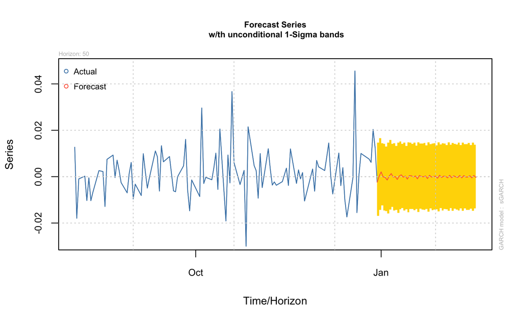

[output not shown]

```r
3
```

[output not shown]

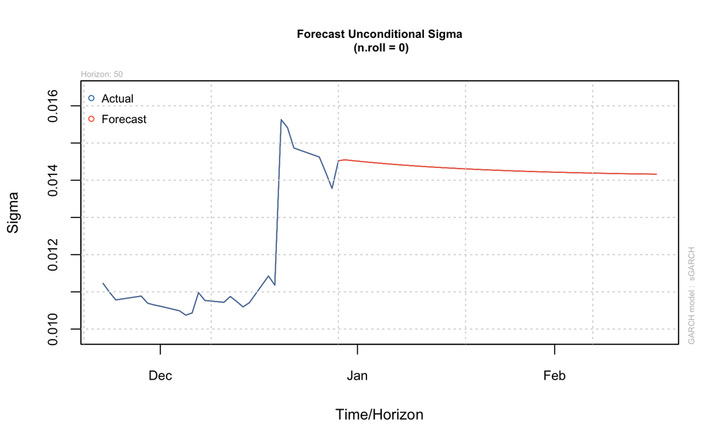

```r
4
```